# Risk Factor Analysis

## Outcome Variable

**Outcome Variable:** y_rate_wtkg

## Predictor Variables

**Intervention Variable:** fhtcm

**Adjustment Set:**

- arm
- W_mage
- W_fage
- meducyrs
- feducyrs
- W_mhtcm
- W_mwtkg
- W_mbmi
- single
- delta_W_fage
- delta_meducyrs
- delta_feducyrs
- delta_W_mhtcm
- delta_W_mwtkg
- delta_W_mbmi
- delta_single

## Stratifying Variables

The analysis was stratified on these variable(s):

- agecat
- studyid
- country

## Data Summary

| agecat | studyid | country | fhtcm | n_cell | n |
| --- | --- | --- | --- | --- | --- |
| 0-3 months | COHORTS | GUATEMALA | >=167 cm | 37 | 243 |
| 0-3 months | COHORTS | GUATEMALA | <162 cm | 141 | 243 |
| 0-3 months | COHORTS | GUATEMALA | [162-167) cm | 65 | 243 |
| 0-3 months | Keneba | GAMBIA | >=167 cm | 768 | 1181 |
| 0-3 months | Keneba | GAMBIA | <162 cm | 82 | 1181 |
| 0-3 months | Keneba | GAMBIA | [162-167) cm | 331 | 1181 |
| 0-3 months | PROBIT | BELARUS | >=167 cm | 10778 | 11505 |
| 0-3 months | PROBIT | BELARUS | <162 cm | 151 | 11505 |
| 0-3 months | PROBIT | BELARUS | [162-167) cm | 576 | 11505 |
| 0-3 months | SAS-CompFeed | INDIA | >=167 cm | 347 | 768 |
| 0-3 months | SAS-CompFeed | INDIA | <162 cm | 197 | 768 |
| 0-3 months | SAS-CompFeed | INDIA | [162-167) cm | 224 | 768 |
| 3-6 months | COHORTS | GUATEMALA | >=167 cm | 37 | 263 |
| 3-6 months | COHORTS | GUATEMALA | <162 cm | 150 | 263 |
| 3-6 months | COHORTS | GUATEMALA | [162-167) cm | 76 | 263 |
| 3-6 months | Keneba | GAMBIA | >=167 cm | 673 | 1039 |
| 3-6 months | Keneba | GAMBIA | <162 cm | 75 | 1039 |
| 3-6 months | Keneba | GAMBIA | [162-167) cm | 291 | 1039 |
| 3-6 months | PROBIT | BELARUS | >=167 cm | 9478 | 10109 |
| 3-6 months | PROBIT | BELARUS | <162 cm | 129 | 10109 |
| 3-6 months | PROBIT | BELARUS | [162-167) cm | 502 | 10109 |
| 3-6 months | SAS-CompFeed | INDIA | >=167 cm | 309 | 681 |
| 3-6 months | SAS-CompFeed | INDIA | <162 cm | 173 | 681 |
| 3-6 months | SAS-CompFeed | INDIA | [162-167) cm | 199 | 681 |
| 6-9 months | COHORTS | GUATEMALA | >=167 cm | 40 | 309 |
| 6-9 months | COHORTS | GUATEMALA | <162 cm | 187 | 309 |
| 6-9 months | COHORTS | GUATEMALA | [162-167) cm | 82 | 309 |
| 6-9 months | Keneba | GAMBIA | >=167 cm | 442 | 663 |
| 6-9 months | Keneba | GAMBIA | <162 cm | 53 | 663 |
| 6-9 months | Keneba | GAMBIA | [162-167) cm | 168 | 663 |

[output cut: 72 more lines]

The following strata were considered:

- agecat: 0-3 months, studyid: COHORTS, country: GUATEMALA
- agecat: 0-3 months, studyid: Keneba, country: GAMBIA
- agecat: 0-3 months, studyid: PROBIT, country: BELARUS
- agecat: 0-3 months, studyid: SAS-CompFeed, country: INDIA
- agecat: 12-15 months, studyid: COHORTS, country: GUATEMALA
- agecat: 12-15 months, studyid: Keneba, country: GAMBIA
- agecat: 12-15 months, studyid: PROBIT, country: BELARUS
- agecat: 12-15 months, studyid: SAS-CompFeed, country: INDIA
- agecat: 12-15 months, studyid: SAS-FoodSuppl, country: INDIA
- agecat: 15-18 months, studyid: COHORTS, country: GUATEMALA
- agecat: 15-18 months, studyid: Keneba, country: GAMBIA
- agecat: 15-18 months, studyid: PROBIT, country: BELARUS
- agecat: 15-18 months, studyid: SAS-CompFeed, country: INDIA
- agecat: 15-18 months, studyid: SAS-FoodSuppl, country: INDIA
- agecat: 18-21 months, studyid: COHORTS, country: GUATEMALA
- agecat: 18-21 months, studyid: Keneba, country: GAMBIA
- agecat: 18-21 months, studyid: PROBIT, country: BELARUS
- agecat: 21-24 months, studyid: COHORTS, country: GUATEMALA
- agecat: 21-24 months, studyid: Keneba, country: GAMBIA
- agecat: 21-24 months, studyid: PROBIT, country: BELARUS
- agecat: 3-6 months, studyid: COHORTS, country: GUATEMALA
- agecat: 3-6 months, studyid: Keneba, country: GAMBIA
- agecat: 3-6 months, studyid: PROBIT, country: BELARUS
- agecat: 3-6 months, studyid: SAS-CompFeed, country: INDIA
- agecat: 6-9 months, studyid: COHORTS, country: GUATEMALA
- agecat: 6-9 months, studyid: Keneba, country: GAMBIA
- agecat: 6-9 months, studyid: PROBIT, country: BELARUS
- agecat: 6-9 months, studyid: SAS-CompFeed, country: INDIA
- agecat: 6-9 months, studyid: SAS-FoodSuppl, country: INDIA
- agecat: 9-12 months, studyid: COHORTS, country: GUATEMALA
- agecat: 9-12 months, studyid: Keneba, country: GAMBIA
- agecat: 9-12 months, studyid: PROBIT, country: BELARUS
- agecat: 9-12 months, studyid: SAS-CompFeed, country: INDIA
- agecat: 9-12 months, studyid: SAS-FoodSuppl, country: INDIA

### Dropped Strata

Some strata were dropped due to rare outcomes:

- agecat: 15-18 months, studyid: PROBIT, country: BELARUS
- agecat: 18-21 months, studyid: PROBIT, country: BELARUS
- agecat: 21-24 months, studyid: PROBIT, country: BELARUS

## Methods Detail

We’re interested in the causal parameters $E[Y_a]$ for all values of $a \in \mathcal{A}$. These parameters represent the mean outcome if, possibly contrary to fact, we intervened to set all units to have $A=a$. Under the randomization and positivity assumptions, these are identified by the statistical parameters $\psi_a=E_W[E_{Y|A,W}(Y|A=a,W)]$. In addition, we’re interested in the mean of $Y$, $E[Y]$ under no intervention (the observed mean). We will estimate these parameters by using SuperLearner to fit the relevant likelihood factors – $E_{Y|A,W}(Y|A=a,W)$ and $p(A=a|W)$, and then updating our likelihood fit using a joint TMLE.

For unadjusted analyses ($W=\{\}$), initial likelihoods were estimated using Lrnr_glm to estimate the simple $E(Y|A)$ and Lrnr_mean to estimate $p(A)$. For adjusted analyses, a small library containing Lrnr_glmnet, Lrnr_xgboost, and Lrnr_mean was used.

# Results Detail

## Results Plots

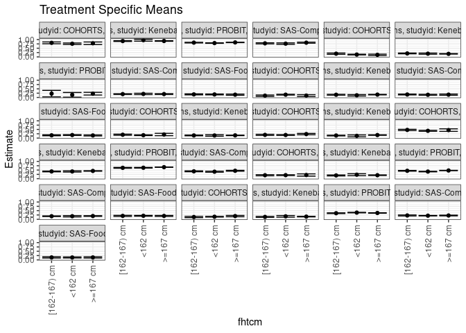

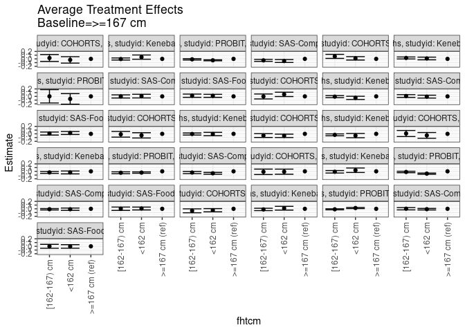

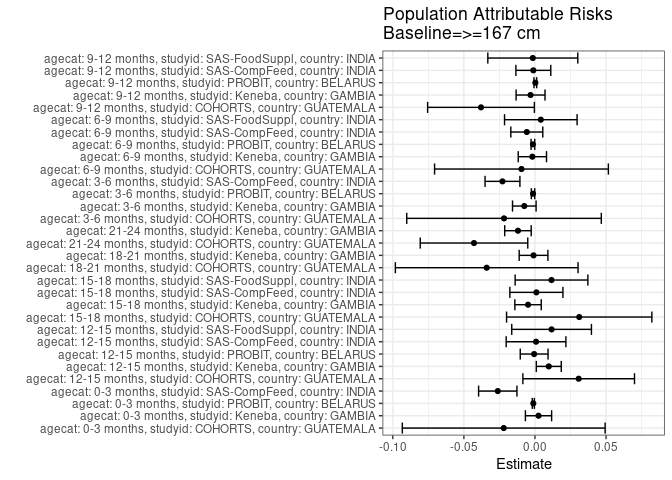

## Results Table

### Parameter: TSM

| agecat | studyid | country | intervention_level | baseline_level | estimate | ci_lower | ci_upper |
| --- | --- | --- | --- | --- | --- | --- | --- |
| 0-3 months | COHORTS | GUATEMALA | >=167 cm | NA | 0.7874761 | 0.7125380 | 0.8624143 |
| 0-3 months | COHORTS | GUATEMALA | <162 cm | NA | 0.7604638 | 0.7178726 | 0.8030550 |
| 0-3 months | COHORTS | GUATEMALA | [162-167) cm | NA | 0.8114784 | 0.7581591 | 0.8647977 |
| 0-3 months | Keneba | GAMBIA | >=167 cm | NA | 0.9186527 | 0.9031515 | 0.9341539 |
| 0-3 months | Keneba | GAMBIA | <162 cm | NA | 0.9660752 | 0.9112577 | 1.0208927 |
| 0-3 months | Keneba | GAMBIA | [162-167) cm | NA | 0.9147990 | 0.8917444 | 0.9378535 |
| 0-3 months | PROBIT | BELARUS | >=167 cm | NA | 0.8368254 | 0.8263473 | 0.8473035 |
| 0-3 months | PROBIT | BELARUS | <162 cm | NA | 0.7988463 | 0.7852826 | 0.8124099 |
| 0-3 months | PROBIT | BELARUS | [162-167) cm | NA | 0.8248344 | 0.8064698 | 0.8431991 |
| 0-3 months | SAS-CompFeed | INDIA | >=167 cm | NA | 0.8222091 | 0.7924112 | 0.8520069 |
| 0-3 months | SAS-CompFeed | INDIA | <162 cm | NA | 0.7651760 | 0.7224902 | 0.8078618 |
| 0-3 months | SAS-CompFeed | INDIA | [162-167) cm | NA | 0.7825087 | 0.7499434 | 0.8150740 |
| 3-6 months | COHORTS | GUATEMALA | >=167 cm | NA | 0.4623175 | 0.3889394 | 0.5356956 |
| 3-6 months | COHORTS | GUATEMALA | <162 cm | NA | 0.4207147 | 0.3940469 | 0.4473825 |
| 3-6 months | COHORTS | GUATEMALA | [162-167) cm | NA | 0.4719157 | 0.4368251 | 0.5070063 |
| 3-6 months | Keneba | GAMBIA | >=167 cm | NA | 0.4489042 | 0.4352720 | 0.4625364 |
| 3-6 months | Keneba | GAMBIA | <162 cm | NA | 0.4191456 | 0.3830369 | 0.4552543 |
| 3-6 months | Keneba | GAMBIA | [162-167) cm | NA | 0.4198074 | 0.3978292 | 0.4417857 |
| 3-6 months | PROBIT | BELARUS | >=167 cm | NA | 0.6667936 | 0.6587137 | 0.6748735 |
| 3-6 months | PROBIT | BELARUS | <162 cm | NA | 0.6333159 | 0.6134703 | 0.6531615 |
| 3-6 months | PROBIT | BELARUS | [162-167) cm | NA | 0.6285636 | 0.6054032 | 0.6517240 |
| 3-6 months | SAS-CompFeed | INDIA | >=167 cm | NA | 0.4585280 | 0.4337131 | 0.4833430 |
| 3-6 months | SAS-CompFeed | INDIA | <162 cm | NA | 0.4053813 | 0.3762891 | 0.4344734 |
| 3-6 months | SAS-CompFeed | INDIA | [162-167) cm | NA | 0.4266601 | 0.4016604 | 0.4516599 |
| 6-9 months | COHORTS | GUATEMALA | >=167 cm | NA | 0.2139375 | 0.1485963 | 0.2792787 |
| 6-9 months | COHORTS | GUATEMALA | <162 cm | NA | 0.2043799 | 0.1826554 | 0.2261044 |
| 6-9 months | COHORTS | GUATEMALA | [162-167) cm | NA | 0.2011881 | 0.1688399 | 0.2335363 |
| 6-9 months | Keneba | GAMBIA | >=167 cm | NA | 0.2014926 | 0.1845117 | 0.2184735 |
| 6-9 months | Keneba | GAMBIA | <162 cm | NA | 0.2307265 | 0.1732163 | 0.2882368 |
| 6-9 months | Keneba | GAMBIA | [162-167) cm | NA | 0.1893851 | 0.1609948 | 0.2177754 |

[output cut: 63 more lines]

### Parameter: E(Y)

| agecat | studyid | country | intervention_level | baseline_level | estimate | ci_lower | ci_upper |
| --- | --- | --- | --- | --- | --- | --- | --- |
| 0-3 months | COHORTS | GUATEMALA | NA | NA | 0.7654973 | 0.7339322 | 0.7970623 |
| 0-3 months | Keneba | GAMBIA | NA | NA | 0.9211456 | 0.9088113 | 0.9334799 |
| 0-3 months | PROBIT | BELARUS | NA | NA | 0.8356651 | 0.8251745 | 0.8461557 |
| 0-3 months | SAS-CompFeed | INDIA | NA | NA | 0.7960458 | 0.7686355 | 0.8234560 |
| 3-6 months | COHORTS | GUATEMALA | NA | NA | 0.4405506 | 0.4209873 | 0.4601139 |
| 3-6 months | Keneba | GAMBIA | NA | NA | 0.4414007 | 0.4306421 | 0.4521592 |
| 3-6 months | PROBIT | BELARUS | NA | NA | 0.6654416 | 0.6574980 | 0.6733852 |
| 3-6 months | SAS-CompFeed | INDIA | NA | NA | 0.4356742 | 0.4152410 | 0.4561073 |
| 6-9 months | COHORTS | GUATEMALA | NA | NA | 0.2044428 | 0.1875679 | 0.2213176 |
| 6-9 months | Keneba | GAMBIA | NA | NA | 0.1996667 | 0.1855792 | 0.2137542 |
| 6-9 months | PROBIT | BELARUS | NA | NA | 0.4728240 | 0.4638757 | 0.4817724 |
| 6-9 months | SAS-CompFeed | INDIA | NA | NA | 0.1837219 | 0.1641903 | 0.2032534 |
| 6-9 months | SAS-FoodSuppl | INDIA | NA | NA | 0.1989315 | 0.1824576 | 0.2154054 |
| 9-12 months | COHORTS | GUATEMALA | NA | NA | 0.1482194 | 0.1336860 | 0.1627527 |
| 9-12 months | Keneba | GAMBIA | NA | NA | 0.1517153 | 0.1384995 | 0.1649312 |
| 9-12 months | PROBIT | BELARUS | NA | NA | 0.3657561 | 0.3510684 | 0.3804439 |
| 9-12 months | SAS-CompFeed | INDIA | NA | NA | 0.2183762 | 0.2032601 | 0.2334924 |
| 9-12 months | SAS-FoodSuppl | INDIA | NA | NA | 0.1420248 | 0.1229762 | 0.1610734 |
| 12-15 months | COHORTS | GUATEMALA | NA | NA | 0.1495595 | 0.1344884 | 0.1646306 |
| 12-15 months | Keneba | GAMBIA | NA | NA | 0.1849266 | 0.1739388 | 0.1959143 |
| 12-15 months | PROBIT | BELARUS | NA | NA | 0.2199602 | 0.1433467 | 0.2965737 |
| 12-15 months | SAS-CompFeed | INDIA | NA | NA | 0.1982163 | 0.1855655 | 0.2108670 |
| 12-15 months | SAS-FoodSuppl | INDIA | NA | NA | 0.1741570 | 0.1580782 | 0.1902359 |
| 15-18 months | COHORTS | GUATEMALA | NA | NA | 0.1392318 | 0.1223264 | 0.1561372 |
| 15-18 months | Keneba | GAMBIA | NA | NA | 0.1612322 | 0.1498772 | 0.1725872 |
| 15-18 months | SAS-CompFeed | INDIA | NA | NA | 0.1646882 | 0.1450730 | 0.1843033 |
| 15-18 months | SAS-FoodSuppl | INDIA | NA | NA | 0.1645149 | 0.1487075 | 0.1803222 |
| 18-21 months | COHORTS | GUATEMALA | NA | NA | 0.1732169 | 0.1574345 | 0.1889994 |
| 18-21 months | Keneba | GAMBIA | NA | NA | 0.1562372 | 0.1442891 | 0.1681853 |
| 21-24 months | COHORTS | GUATEMALA | NA | NA | 0.1888602 | 0.1739625 | 0.2037579 |
| 21-24 months | Keneba | GAMBIA | NA | NA | 0.1630013 | 0.1513318 | 0.1746708 |

### Parameter: ATE

| agecat | studyid | country | intervention_level | baseline_level | estimate | ci_lower | ci_upper |
| --- | --- | --- | --- | --- | --- | --- | --- |
| 0-3 months | COHORTS | GUATEMALA | >=167 cm | >=167 cm | 0.0000000 | 0.0000000 | 0.0000000 |
| 0-3 months | COHORTS | GUATEMALA | <162 cm | >=167 cm | -0.0270123 | -0.1131229 | 0.0590983 |
| 0-3 months | COHORTS | GUATEMALA | [162-167) cm | >=167 cm | 0.0240023 | -0.0682206 | 0.1162251 |
| 0-3 months | Keneba | GAMBIA | >=167 cm | >=167 cm | 0.0000000 | 0.0000000 | 0.0000000 |
| 0-3 months | Keneba | GAMBIA | <162 cm | >=167 cm | 0.0474225 | -0.0096166 | 0.1044616 |
| 0-3 months | Keneba | GAMBIA | [162-167) cm | >=167 cm | -0.0038537 | -0.0313912 | 0.0236837 |
| 0-3 months | PROBIT | BELARUS | >=167 cm | >=167 cm | 0.0000000 | 0.0000000 | 0.0000000 |
| 0-3 months | PROBIT | BELARUS | <162 cm | >=167 cm | -0.0379791 | -0.0513927 | -0.0245655 |
| 0-3 months | PROBIT | BELARUS | [162-167) cm | >=167 cm | -0.0119910 | -0.0300931 | 0.0061111 |
| 0-3 months | SAS-CompFeed | INDIA | >=167 cm | >=167 cm | 0.0000000 | 0.0000000 | 0.0000000 |
| 0-3 months | SAS-CompFeed | INDIA | <162 cm | >=167 cm | -0.0570331 | -0.0957101 | -0.0183561 |
| 0-3 months | SAS-CompFeed | INDIA | [162-167) cm | >=167 cm | -0.0397004 | -0.0660754 | -0.0133253 |
| 3-6 months | COHORTS | GUATEMALA | >=167 cm | >=167 cm | 0.0000000 | 0.0000000 | 0.0000000 |
| 3-6 months | COHORTS | GUATEMALA | <162 cm | >=167 cm | -0.0416028 | -0.1197806 | 0.0365750 |
| 3-6 months | COHORTS | GUATEMALA | [162-167) cm | >=167 cm | 0.0095982 | -0.0717907 | 0.0909870 |
| 3-6 months | Keneba | GAMBIA | >=167 cm | >=167 cm | 0.0000000 | 0.0000000 | 0.0000000 |
| 3-6 months | Keneba | GAMBIA | <162 cm | >=167 cm | -0.0297586 | -0.0684048 | 0.0088875 |
| 3-6 months | Keneba | GAMBIA | [162-167) cm | >=167 cm | -0.0290968 | -0.0549388 | -0.0032548 |
| 3-6 months | PROBIT | BELARUS | >=167 cm | >=167 cm | 0.0000000 | 0.0000000 | 0.0000000 |
| 3-6 months | PROBIT | BELARUS | <162 cm | >=167 cm | -0.0334777 | -0.0514561 | -0.0154992 |
| 3-6 months | PROBIT | BELARUS | [162-167) cm | >=167 cm | -0.0382299 | -0.0628871 | -0.0135727 |
| 3-6 months | SAS-CompFeed | INDIA | >=167 cm | >=167 cm | 0.0000000 | 0.0000000 | 0.0000000 |
| 3-6 months | SAS-CompFeed | INDIA | <162 cm | >=167 cm | -0.0531468 | -0.0773195 | -0.0289740 |
| 3-6 months | SAS-CompFeed | INDIA | [162-167) cm | >=167 cm | -0.0318679 | -0.0608315 | -0.0029043 |
| 6-9 months | COHORTS | GUATEMALA | >=167 cm | >=167 cm | 0.0000000 | 0.0000000 | 0.0000000 |
| 6-9 months | COHORTS | GUATEMALA | <162 cm | >=167 cm | -0.0095576 | -0.0784925 | 0.0593773 |
| 6-9 months | COHORTS | GUATEMALA | [162-167) cm | >=167 cm | -0.0127494 | -0.0858536 | 0.0603547 |
| 6-9 months | Keneba | GAMBIA | >=167 cm | >=167 cm | 0.0000000 | 0.0000000 | 0.0000000 |
| 6-9 months | Keneba | GAMBIA | <162 cm | >=167 cm | 0.0292339 | -0.0306548 | 0.0891226 |
| 6-9 months | Keneba | GAMBIA | [162-167) cm | >=167 cm | -0.0121075 | -0.0453283 | 0.0211132 |

[output cut: 63 more lines]

### Parameter: PAR

| agecat | studyid | country | intervention_level | baseline_level | estimate | ci_lower | ci_upper |
| --- | --- | --- | --- | --- | --- | --- | --- |
| 0-3 months | COHORTS | GUATEMALA | >=167 cm | NA | -0.0219789 | -0.0933001 | 0.0493424 |
| 0-3 months | Keneba | GAMBIA | >=167 cm | NA | 0.0024929 | -0.0067222 | 0.0117081 |
| 0-3 months | PROBIT | BELARUS | >=167 cm | NA | -0.0011603 | -0.0018986 | -0.0004220 |
| 0-3 months | SAS-CompFeed | INDIA | >=167 cm | NA | -0.0261633 | -0.0396486 | -0.0126780 |
| 3-6 months | COHORTS | GUATEMALA | >=167 cm | NA | -0.0217669 | -0.0901907 | 0.0466569 |
| 3-6 months | Keneba | GAMBIA | >=167 cm | NA | -0.0075035 | -0.0157934 | 0.0007863 |
| 3-6 months | PROBIT | BELARUS | >=167 cm | NA | -0.0013520 | -0.0025390 | -0.0001649 |
| 3-6 months | SAS-CompFeed | INDIA | >=167 cm | NA | -0.0228538 | -0.0351170 | -0.0105907 |
| 6-9 months | COHORTS | GUATEMALA | >=167 cm | NA | -0.0094948 | -0.0706223 | 0.0516328 |
| 6-9 months | Keneba | GAMBIA | >=167 cm | NA | -0.0018259 | -0.0117710 | 0.0081192 |
| 6-9 months | PROBIT | BELARUS | >=167 cm | NA | -0.0014537 | -0.0027329 | -0.0001746 |
| 6-9 months | SAS-CompFeed | INDIA | >=167 cm | NA | -0.0057483 | -0.0169909 | 0.0054944 |
| 6-9 months | SAS-FoodSuppl | INDIA | >=167 cm | NA | 0.0041097 | -0.0214027 | 0.0296221 |
| 9-12 months | COHORTS | GUATEMALA | >=167 cm | NA | -0.0379537 | -0.0755069 | -0.0004006 |
| 9-12 months | Keneba | GAMBIA | >=167 cm | NA | -0.0031018 | -0.0132676 | 0.0070639 |
| 9-12 months | PROBIT | BELARUS | >=167 cm | NA | 0.0002644 | -0.0006862 | 0.0012149 |
| 9-12 months | SAS-CompFeed | INDIA | >=167 cm | NA | -0.0011390 | -0.0134092 | 0.0111311 |
| 9-12 months | SAS-FoodSuppl | INDIA | >=167 cm | NA | -0.0015280 | -0.0331652 | 0.0301091 |
| 12-15 months | COHORTS | GUATEMALA | >=167 cm | NA | 0.0307454 | -0.0085116 | 0.0700024 |
| 12-15 months | Keneba | GAMBIA | >=167 cm | NA | 0.0097143 | 0.0009432 | 0.0184855 |
| 12-15 months | PROBIT | BELARUS | >=167 cm | NA | -0.0005776 | -0.0103493 | 0.0091940 |
| 12-15 months | SAS-CompFeed | INDIA | >=167 cm | NA | 0.0007473 | -0.0202558 | 0.0217504 |
| 12-15 months | SAS-FoodSuppl | INDIA | >=167 cm | NA | 0.0116871 | -0.0163399 | 0.0397141 |
| 15-18 months | COHORTS | GUATEMALA | >=167 cm | NA | 0.0311224 | -0.0199768 | 0.0822216 |
| 15-18 months | Keneba | GAMBIA | >=167 cm | NA | -0.0048633 | -0.0141469 | 0.0044202 |
| 15-18 months | SAS-CompFeed | INDIA | >=167 cm | NA | 0.0010026 | -0.0176579 | 0.0196631 |
| 15-18 months | SAS-FoodSuppl | INDIA | >=167 cm | NA | 0.0116315 | -0.0139502 | 0.0372132 |
| 18-21 months | COHORTS | GUATEMALA | >=167 cm | NA | -0.0339521 | -0.0981947 | 0.0302904 |
| 18-21 months | Keneba | GAMBIA | >=167 cm | NA | -0.0010028 | -0.0110995 | 0.0090939 |
| 21-24 months | COHORTS | GUATEMALA | >=167 cm | NA | -0.0428830 | -0.0806965 | -0.0050695 |
| 21-24 months | Keneba | GAMBIA | >=167 cm | NA | -0.0119603 | -0.0212761 | -0.0026444 |